# 06_analysis_2

## Loading libraries

```r
library("tidyverse")
library("DescTools")
```

## Loading augmented data

```r
kidney_merged_GFR <- read_rds("../data/03_data_augment.rds")
```

## Prepare variables for Analysis

Here we make sure that the key categorical variables are treated as factors and that the CKD stages have an ordered structure.

```r
kidney_analysis <- kidney_merged_GFR |>
mutate(
  classification = as.factor(classification),
  hypertension = as.factor(hypertension),
  diabetes_mellitus = as.factor(diabetes_mellitus),
  coronary_artery_disease = as.factor(coronary_artery_disease),
  anemia = as.factor(anemia),
  pedal_edema = as.factor(pedal_edema),
  cdk_stage = factor(
    cdk_stage,
    levels = c("stage_1", "stage_2", "stage_3a", "stage_3b", "stage_4", "stage_5"),
    ordered = TRUE
    )
  )

kidney_analysis |>
  write_rds("../data/04_data_analysis.rds")
```

## Question 1: Is kidney function (GFR) lower in CKD patients?

We expect individuals with a CKD diagnosis to have lower estimated glomerular filtration rate (GFR).

```r
kidney_analysis |>
  drop_na(GFR_average, classification) |>
  group_by(classification) |>
  summarise(
    n = n(),
    mean_GFR = mean(GFR_average),
    median_GFR = median(GFR_average),
    sd_GFR = sd(GFR_average)
    )
```

```
# A tibble: 2 × 5
  classification     n mean_GFR median_GFR sd_GFR
  <fct>          <int>    <dbl>      <dbl>  <dbl>
1 ckd              230     36.7       28.6   32.6
2 notckd           144     94.1       94.4   23.3
```

Visualize GFR by CKD classification

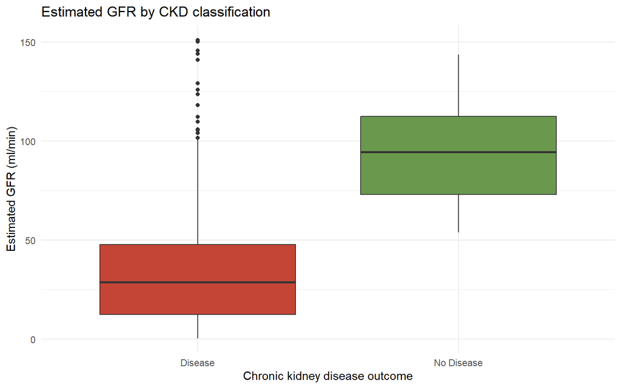

```r
kidney_analysis |>
  drop_na(GFR_average, classification) |>
  ggplot(aes(x = classification, y = GFR_average, fill = classification)) +
  geom_boxplot() +
  theme_minimal() +
  theme(legend.position="none") +
  labs(
    title = "Estimated GFR by CKD classification",
    x = "Chronic kidney disease outcome",
    y = "Estimated GFR (ml/min)") +
  scale_x_discrete(
    labels = c("ckd" = "Disease", "notckd" = "No Disease")) +
  scale_fill_manual(
    values = c("ckd" = "#C44536", "notckd" = "#6A994E"))
```

```r
ggsave(
    filename = "../results/06_gfr_by_ckd.png"
  )
```

## Question 2: How are CKD stages distributed between diagnosed and non-diagnosed individuals?

Here we look at how the GFR-based CKD stages are distributed in people with and without a CKD diagnosis.

```r
kidney_analysis |>
  drop_na(cdk_stage, classification) |>
  count(cdk_stage, classification) |>
  group_by(classification) |>
  mutate(prop = n / sum(n))
```

```
# A tibble: 9 × 4
# Groups:   classification [2]
  cdk_stage classification     n   prop
  <ord>     <fct>          <int>  <dbl>
1 stage_1   ckd               20 0.0870
2 stage_1   notckd            81 0.562
3 stage_2   ckd               22 0.0957
4 stage_2   notckd            61 0.424
5 stage_3a  ckd               22 0.0957
6 stage_3a  notckd             2 0.0139
7 stage_3b  ckd               47 0.204
8 stage_4   ckd               55 0.239
9 stage_5   ckd               64 0.278
```

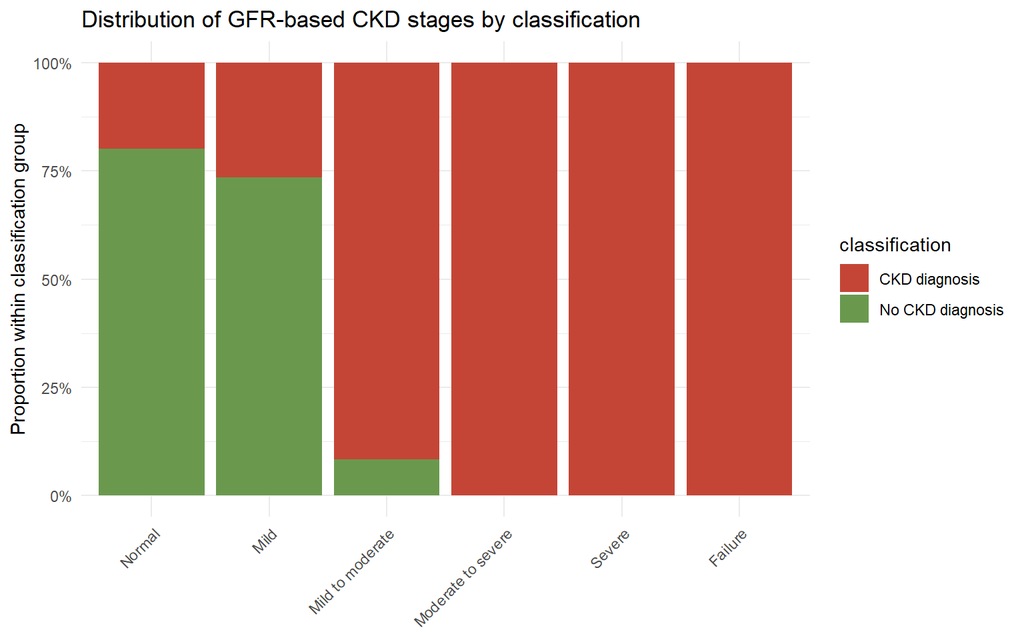

```r
stage_labs <- c("Normal",
                "Mild",
                "Mild to moderate",
                "Moderate to severe",
                "Severe",
                "Failure")

kidney_analysis |>
  drop_na(cdk_stage, classification) |>
  ggplot(aes(x = cdk_stage, fill = classification)) +
  geom_bar(position = "fill") +
  theme_minimal() +
  theme(axis.text.x = element_text(angle = 45, hjust = 1)) +
  labs(
    title = "Distribution of GFR-based CKD stages by classification",
    x = NULL,
    y = "Proportion within classification group"
    ) +
  scale_y_continuous(labels = scales::percent_format()) +
  scale_fill_manual(
    values = c("ckd" = "#C44536", "notckd" = "#6A994E"),
    labels = c("ckd" = "CKD diagnosis", "notckd" = "No CKD diagnosis")) +
  scale_x_discrete(labels = stage_labs)
```

```r
ggsave(
    filename = "../results/06_CKD_dist.png"
  )
```

## Question 3: Are hypertension and diabetes more common among CKD patients?

Hypertension and diabetes are known risk factors for CKD. Here we compare their prevalence between groups.

```r
kidney_analysis |>
  drop_na(c(hypertension, classification)) |>
  count(classification, hypertension) |>
  group_by(classification) |>
  mutate(prop = n / sum(n))
```

```
# A tibble: 3 × 4
# Groups:   classification [2]
  classification hypertension     n  prop
  <fct>          <fct>        <int> <dbl>
1 ckd            no             103 0.412
2 ckd            yes            147 0.588
3 notckd         no             148 1
```

Visualization

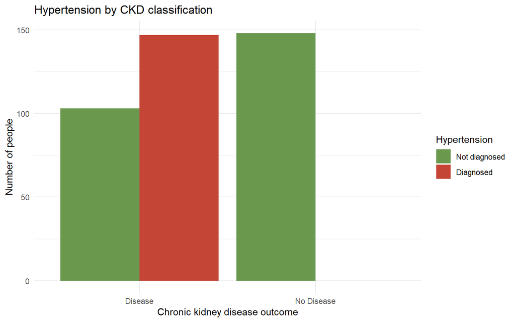

```r
kidney_analysis |>
  drop_na(c(hypertension, classification)) |>
  ggplot(aes(x = classification, fill = hypertension)) +
  geom_bar(
    position = position_dodge(preserve = "single")) +
  theme_minimal() +
  labs(
    title = "Hypertension by CKD classification",
    fill = "Hypertension",
    x = "Chronic kidney disease outcome",
    y = "Number of people") +
  scale_x_discrete(
    labels = c("ckd" = "Disease", "notckd" = "No Disease")) +
  scale_fill_manual(
    values = c("yes" = "#C44536", "no" = "#6A994E"),
    labels = c("yes" = "Diagnosed", "no" = "Not diagnosed"))
```

```r
ggsave(
    filename = "../results/06_CKD_hypertension.png"
  )
```

## Diabetes vs Classification

```r
kidney_analysis |>
  drop_na(diabetes_mellitus, classification) |>
  count(classification, diabetes_mellitus) |>
  group_by(classification) |>
  mutate(prop = n / sum(n))
```

```
# A tibble: 3 × 4
# Groups:   classification [2]
  classification diabetes_mellitus     n  prop
  <fct>          <fct>             <int> <dbl>
1 ckd            no                  113 0.452
2 ckd            yes                 137 0.548
3 notckd         no                  148 1
```

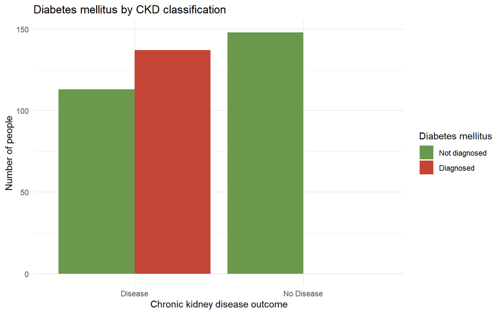

```r
kidney_analysis |>
  drop_na(diabetes_mellitus, classification) |>
  ggplot(aes(x = classification, fill = diabetes_mellitus)) +
  geom_bar(position = position_dodge(preserve = "single")) +
  theme_minimal() +
  labs(
    title = "Diabetes mellitus by CKD classification",
    fill = "Diabetes mellitus",
    x = "Chronic kidney disease outcome",
    y = "Number of people") +
  scale_x_discrete(
    labels = c("ckd" = "Disease", "notckd" = "No Disease")) +
  scale_fill_manual(
    values = c("yes" = "#C44536", "no" = "#6A994E"),
    labels = c("yes" = "Diagnosed", "no" = "Not diagnosed"))
```

```r
ggsave(
    filename = "../results/06_CKD_diabetes.png"
  )
```